# “COMPSCIX 415.2 Homework 4

Chunduri SriKeerthi Chandra

Jul 3rd 2018

## **Data munging and data wrangling**

### 5.6.7 Exercises

**Q:** Come up with another approach that will give you the same output as not_cancelled %>% count(dest) and not_cancelled %>% count(tailnum, wt = distance) (without using count()).

```r
not_cancelled <- flights %>%
  filter(!is.na(dep_delay), !is.na(arr_delay))
```

Total number of flights not canceled for a destination can also be computed as

```r
not_cancelled %>% group_by(dest) %>% summarise(n())
```

```
## # A tibble: 104 x 2
##    dest  `n()`
##    <chr> <int>
##  1 ABQ     254
##  2 ACK     264
##  3 ALB     418
##  4 ANC       8
##  5 ATL   16837
##  6 AUS    2411
##  7 AVL     261
##  8 BDL     412
##  9 BGR     358
## 10 BHM     269
## # ... with 94 more rows
```

Totla distance each flight flew can be computed as:

```r
not_cancelled %>% group_by(tailnum) %>% summarise(n = sum(distance))
```

```
## # A tibble: 4,037 x 2
##    tailnum      n
##    <chr>    <dbl>
##  1 D942DN    3418
##  2 N0EGMQ  239143
##  3 N10156  109664
##  4 N102UW   25722
##  5 N103US   24619
##  6 N104UW   24616
##  7 N10575  139903
##  8 N105UW   23618
##  9 N107US   21677
## 10 N108UW   32070
## # ... with 4,027 more rows
```

**Q:** Look at the number of cancelled flights per day. Is there a pattern? Is the proportion of cancelled flights related to the average delay?

```r
mutated_flights <- flights %>% group_by(year, month, day)  %>% mutate(canceled = (is.na(dep_delay) & is.na(arr_delay)))
```

Total number of canceled flights per day are:

```r
mutated_flights %>% summarise(canceled = sum(canceled))
```

```
## # A tibble: 365 x 4
## # Groups:   year, month [?]
##     year month   day canceled
##    <int> <int> <int>    <int>
##  1  2013     1     1        4
##  2  2013     1     2        8
##  3  2013     1     3       10
##  4  2013     1     4        6
##  5  2013     1     5        3
##  6  2013     1     6        1
##  7  2013     1     7        3
##  8  2013     1     8        4
##  9  2013     1     9        5
## 10  2013     1    10        3
## # ... with 355 more rows
```

Comparing average departure delay Vs average flight cancelation:

```r
(data <- mutated_flights %>% summarise( count = n(), canceled = mean(canceled, na.rm = TRUE), delay = mean(dep_delay, na.rm = TRUE)) %>% filter(count > 50))
```

```
## # A tibble: 365 x 6
## # Groups:   year, month [12]
##     year month   day count canceled delay
##    <int> <int> <int> <int>    <dbl> <dbl>
##  1  2013     1     1   842  0.00475 11.5
##  2  2013     1     2   943  0.00848 13.9
##  3  2013     1     3   914  0.0109  11.0
##  4  2013     1     4   915  0.00656  8.95
##  5  2013     1     5   720  0.00417  5.73
##  6  2013     1     6   832  0.00120  7.15
##  7  2013     1     7   933  0.00322  5.42
##  8  2013     1     8   899  0.00445  2.55
##  9  2013     1     9   902  0.00554  2.28
## 10  2013     1    10   932  0.00322  2.84
## # ... with 355 more rows
```

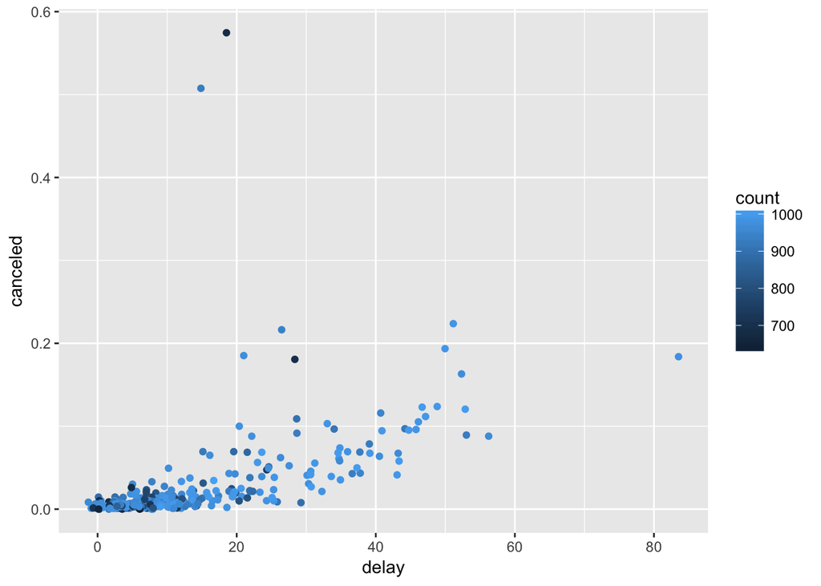

```r
data %>% ggplot() + geom_point(aes(x = delay, y = canceled, color = count), position = "jitter")
```

**Q:** What does the sort argument to count() do. When might you use it?

When *sort* is set to *TRUE* it will arrange the rows in the desending order of n, similar to arrange(desc(n)) verb.

### 10.5 Exercises

**Q:** 1 How can you tell if an object is a tibble? (Hint: try printing mtcars, which is a regular data frame). We can test to see if the object is a tibble like:

```r
is.tibble(flights)
```

```
## [1] TRUE
```

Or we can display the object to tell if its a tibble. Tibbles have a refined print method that shows only the first 10 rows:

```r
flights
```

```
## # A tibble: 336,776 x 19
##     year month   day dep_time sched_dep_time dep_delay arr_time
##    <int> <int> <int>    <int>          <int>     <dbl>    <int>
##  1  2013     1     1      517            515         2      830
##  2  2013     1     1      533            529         4      850
##  3  2013     1     1      542            540         2      923
##  4  2013     1     1      544            545        -1     1004
##  5  2013     1     1      554            600        -6      812
##  6  2013     1     1      554            558        -4      740
##  7  2013     1     1      555            600        -5      913
##  8  2013     1     1      557            600        -3      709
##  9  2013     1     1      557            600        -3      838
## 10  2013     1     1      558            600        -2      753
## # ... with 336,766 more rows, and 12 more variables: sched_arr_time <int>,
## #   arr_delay <dbl>, carrier <chr>, flight <int>, tailnum <chr>,
## #   origin <chr>, dest <chr>, air_time <dbl>, distance <dbl>, hour <dbl>,
## #   minute <dbl>, time_hour <dttm>
```

Or we can check the class of the object

```r
class(flights)
```

```
## [1] "tbl_df"     "tbl"        "data.frame"
```

**Q:**2 Compare and contrast the following operations on a data.frame and equivalent tibble. What is different? Why might the default data frame behaviours cause you frustration? *df <- data.frame(abc = 1, xyz = “a”)* *df$x* *df[, “xyz”]* *df[, c(“abc”, “xyz”)]*

Tibbles are strict when accessing columns using *$* or *[[]]*. Whereas *data.frames* match the nearest column name, as in this case *data.frame* doesn’t have column **x**, but still displays *xyz* value.

```r
df <- data.frame(abc = 1, xyz = "a")
df$x
```

```
## [1] a
## Levels: a
```

```r
df[, "xyz"]
```

```
## [1] a
## Levels: a
```

```r
df[, c("abc", "xyz")]
```

```
##   abc xyz
## 1   1   a
```

Which is not the case with tibbel:

```r
df <- tibble(abc = 1, xyz = "a")
df$x
```

[output not shown]

```r
df[, "xyz"]
```

```
## # A tibble: 1 x 1
##   xyz
##   <chr>
## 1 a
```

```r
df[, c("abc", "xyz")]
```

```
## # A tibble: 1 x 2
##     abc xyz
##   <dbl> <chr>
## 1     1 a
```

And the tibble displays the column type which is more informative compared to nothing on *data.frames*.

**Q:**3 If you have the name of a variable stored in an object, e.g. var <- “mpg”, how can you extract the reference variable from a tibble?

We can use **[[]]** or **$** to read a variable contents from tibble.

**Q:**6 What option controls how many additional column names are printed at the footer of a tibble?

*print()* function can be used to control the number of rows and number of columns to be displayed. *print()* takes variables *n* to control number of rown and *width* to control number of columns.

### 12.3.3 Exercises

**Q:**2 Why does this code fail? *table4a %>%* *gather(1999, 2000, key = “year”, value = “cases”)*

Column names 1999 and 2000 doesn’t start with a letter, since they are non-syntactic names we have to encode them in backticks otherwise R takes them as range.

correct way to transfer:

```r
table4a %>%
  gather(`1999`, `2000`, key = "year", value = "cases")
```

```
## # A tibble: 6 x 3
##   country     year   cases
##   <chr>       <chr>  <int>
## 1 Afghanistan 1999     745
## 2 Brazil      1999   37737
## 3 China       1999  212258
## 4 Afghanistan 2000    2666
## 5 Brazil      2000   80488
## 6 China       2000  213766
```

**Q:**3 Why does spreading this tibble fail? How could you add a new column to fix the problem?

```r
people <- tribble(
  ~name,             ~key,    ~value,
  #-----------------|--------|------
  "Phillip Woods",   "age",       45,
  "Phillip Woods",   "height",   186,
  "Phillip Woods",   "age",       50,
  "Jessica Cordero", "age",       37,
  "Jessica Cordero", "height",   156
)

people %>% spread(key = key, value = value)
```

```
## Error: Duplicate identifiers for rows (1, 3)
```

observations on row 1 and row 3 are duplicate for age, hence spread fails with *Error: Duplicate identifiers for rows (1, 3)* message.

**Note**: Not quite sure how to get around this issue. Not answered.

**Q:**4 Tidy the simple tibble below. Do you need to spread or gather it? What are the variables?

```r
preg <- tribble(
  ~pregnant, ~male, ~female,
  "yes",     NA,    10,
  "no",      20,    12
)
```

We have to gather the male and female in to a colum.

```r
preg %>% gather(male, female, key=gender, value=count)
```

```
## # A tibble: 4 x 3
##   pregnant gender count
##   <chr>    <chr>  <dbl>
## 1 yes      male      NA
## 2 no       male      20
## 3 yes      female    10
## 4 no       female    12
```

### 12.4.3 Exercises

**Q:**1 What do the extra and fill arguments do in separate()? Experiment with the various options for the following two toy datasets.

*extra* argument can be used to control what happens when a split generates more than what is required number of values. And *fill* argument can be used to control how *NA* placed when a split generates less than the required number values.

```r
tibble(x = c("a,b,c", "d,e,f,g", "h,i,j")) %>%
  #Drops the extra value silently
  separate(x, c("one", "two", "three"), extra = "drop")
```

```
## # A tibble: 3 x 3
##   one   two   three
##   <chr> <chr> <chr>
## 1 a     b     c
## 2 d     e     f
## 3 h     i     j
```

```r
tibble(x = c("a,b,c", "d,e", "f,g,i")) %>%
  #Fills NA on the left instead of on the right(default)
  separate(x, c("one", "two", "three"), fill = "left")
```

```
## # A tibble: 3 x 3
##   one   two   three
##   <chr> <chr> <chr>
## 1 a     b     c
## 2 <NA>  d     e
## 3 f     g     i
```

```r
tibble(x = c("a,b,c", "d,e,f,g", "h,i,j")) %>%
  #Only splits at most lenght(into), that means "d,e,f,g" is split in to "d" and "e" and "f,g"
  separate(x, c("one", "two", "three"), extra = "merge")
```

```
## # A tibble: 3 x 3
##   one   two   three
##   <chr> <chr> <chr>
## 1 a     b     c
## 2 d     e     f,g
## 3 h     i     j
```

**Q:**2 Both unite() and separate() have a remove argument. What does it do? Why would you set it to FALSE?

*remove* argument can be used to retain the original column in the output data frame. The default value is *TRUE* which removes the original column, but when it is set to *FALSE* output data frame retains the original column.

Example:

```r
tibble(x = c("a,b,c", "d,e,f,g", "h,i,j")) %>%
  #Drops the extra value silently
  separate(x, c("one", "two", "three"), extra = "drop", remove = FALSE)
```

```
## # A tibble: 3 x 4
##   x       one   two   three
##   <chr>   <chr> <chr> <chr>
## 1 a,b,c   a     b     c
## 2 d,e,f,g d     e     f
## 3 h,i,j   h     i     j
```

### Data Import Exercises

Follow these steps: - Download the baby_names.txt file from Canvas which is in the Homework 4 assignment section. - Load this file into R correctly and take a glimpse of the output. - Export this file as a csv file and call it ‘baby_names.csv’. - Reload the baby_names.csv file and take another glimpse. - Show all of your code and the output.

```r
#Loading baby_names.txt
filePath <- "/Users/srchundu/UCBExtension/DataScienceIntro/compscix-415-2-assignments/Lab4/baby_names.txt"

#File is a "|" seperated
fileData <- read_delim(file = filePath, delim = "|")
#Glimpse at file content
fileData
```

```
## # A tibble: 30,000 x 5
##     year sex   name          n   prop
##    <int> <chr> <chr>     <int>  <dbl>
##  1  1880 F     Mary       7065 0.0724
##  2  1880 F     Anna       2604 0.0267
##  3  1880 F     Emma       2003 0.0205
##  4  1880 F     Elizabeth  1939 0.0199
##  5  1880 F     Minnie     1746 0.0179
##  6  1880 F     Margaret   1578 0.0162
##  7  1880 F     Ida        1472 0.0151
##  8  1880 F     Alice      1414 0.0145
##  9  1880 F     Bertha     1320 0.0135
## 10  1880 F     Sarah      1288 0.0132
## # ... with 29,990 more rows
```

```r
# Write file contents back to CSV file
csvFilePath <- "/Users/srchundu/UCBExtension/DataScienceIntro/compscix-415-2-assignments/Lab4/baby_names.csv"
fileData %>% write_csv(path = csvFilePath)

# Read back baby names from CSV file
fileData2 <- read_csv(file = csvFilePath)
#Glimpse at file content
fileData2
```

```
## # A tibble: 30,000 x 5
##     year sex   name          n   prop
##    <int> <chr> <chr>     <int>  <dbl>
##  1  1880 F     Mary       7065 0.0724
##  2  1880 F     Anna       2604 0.0267
##  3  1880 F     Emma       2003 0.0205
##  4  1880 F     Elizabeth  1939 0.0199
##  5  1880 F     Minnie     1746 0.0179
##  6  1880 F     Margaret   1578 0.0162
##  7  1880 F     Ida        1472 0.0151
##  8  1880 F     Alice      1414 0.0145
##  9  1880 F     Bertha     1320 0.0135
## 10  1880 F     Sarah      1288 0.0132
## # ... with 29,990 more rows
```

### Challenge Question 5.6.7 Exercise

**Q:**5 Which carrier has the worst delays? Challenge: can you disentangle the effects of bad airports vs. bad carriers? Why/why not? (Hint: think about flights %>% group_by(carrier, dest) %>% summarise(n()))

I couldn’t derive the relation between bad airports and bad carriers

Carriers with worst delays:

```r
delayed_flights <- flights %>% filter((!is.na(dep_delay) & dep_delay > 0) | (!is.na(arr_delay) & arr_delay > 0));
delayed_flights %>% group_by(carrier) %>% summarise(total = n()) %>% arrange(desc(total))
```

```
## # A tibble: 16 x 2
##    carrier total
##    <chr>   <int>
##  1 UA      32877
##  2 B6      28618
##  3 EV      28440
##  4 DL      21528
##  5 AA      14200
##  6 MQ      12780
##  7 9E       8645
##  8 US       8359
##  9 WN       7569
## 10 VX       2754
## 11 FL       2163
## 12 F9        477
## 13 YV        293
## 14 AS        290
## 15 HA        129
## 16 OO         11
```

Airports with worst delays:

```r
delayed_flights <- flights %>% filter((!is.na(dep_delay) & dep_delay > 0) | (!is.na(arr_delay) & arr_delay > 0))
delayed_flights %>% group_by(dest) %>% summarise(total = n()) %>% arrange(desc(total))
```

```
## # A tibble: 103 x 2
##    dest  total
##    <chr> <int>
##  1 ATL    9228
##  2 LAX    8625
##  3 ORD    8048
##  4 MCO    7267
##  5 SFO    7237
##  6 CLT    6708
##  7 FLL    6632
##  8 BOS    6104
##  9 MIA    5390
## 10 DCA    4481
## # ... with 93 more rows
```